# Machine Learning

## 8.5 Application

In this example, I will use a continuous y variable.

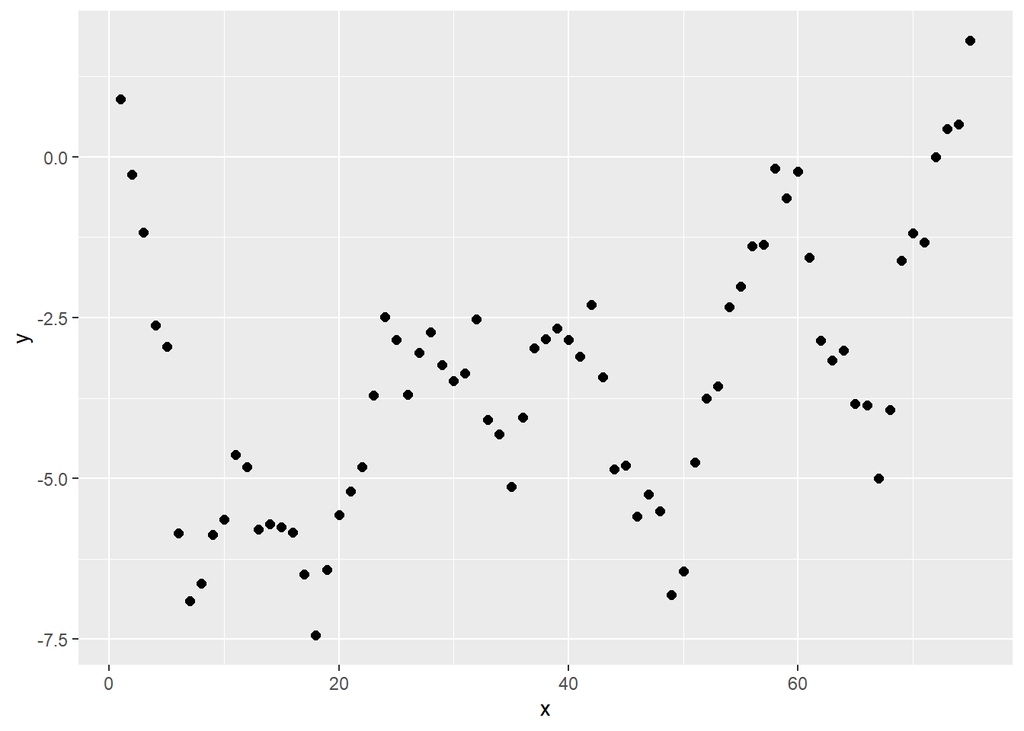

```r
# Generate random data
set.seed(2022)
x = 1:75
y = cumsum((rnorm(length(x))))
dat <- data.frame(x=x, y=y)

# Plot data
ggplot(data = dat, aes(x = x, y = y)) +
  geom_point(size = 2) +
  scale_color_manual(values=c("#000000", "#FF0000")) +
  theme(legend.position = "none")
```

Firstly, use linear regression to compare its performance with that of SVM regression.

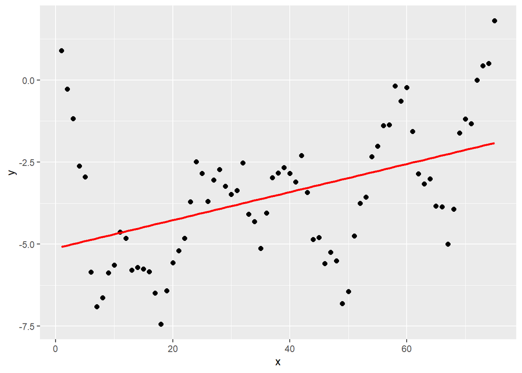

```r
# Fit a linear regression model
fit_linear <- lm(y ~ x, data = dat)

# Make predictions for regression model for each x val
predict_linear <- predict(fit_linear, dat)

# Show predictions with orignal data
ggplot(data = dat, aes(x = x, y = y)) +
  geom_point(size = 2) +
  scale_color_manual(values=c("#000000", "#FF0000")) +
  theme(legend.position = "none") +
  geom_smooth(method = "lm", se = FALSE, color = "red", formula = y ~ x)
```

Now I use support vector regression.

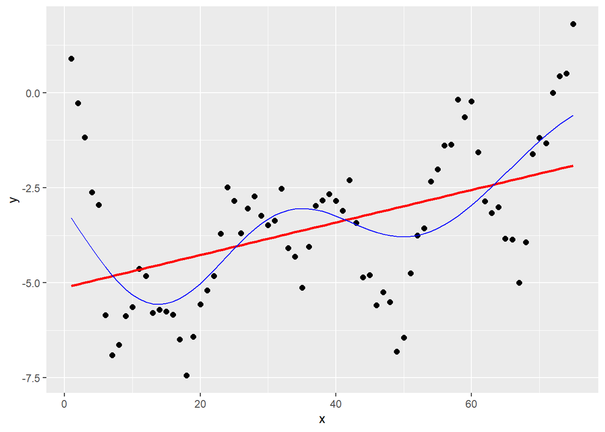

```r
# SVM model
fit_svr <- svm(y ~ x , dat)

# Predicted vals for all X
predict_svr <- predict(fit_svr, dat)

# Plot the results along with the linear regression line
ggplot(data = dat, aes(x = x, y = y)) +
  geom_point(size = 2) +
  scale_color_manual(values=c("#000000", "#FF0000")) +
  theme(legend.position = "none") +
  geom_smooth(method = "lm", se = FALSE, color = "red", formula = y ~ x) + # Linear regression
  geom_line(aes(x = x, y = predict_svr), color = "blue") # SVM regression
```

Tune the cost parameter to identify the best model.

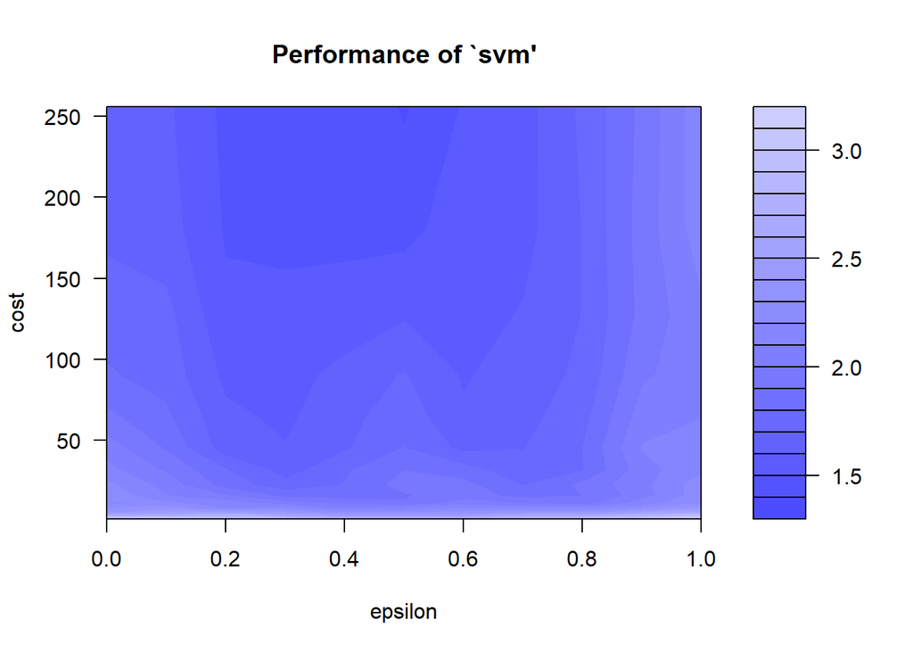

```r
# Perform a grid search
tuneResult <- tune(svm, y ~ x,  data = dat,
              ranges = list(epsilon = seq(0,1,0.1), cost = 2^(seq(0.5,8,.5)))
)

# Map tuning results
plot(tuneResult)
```

Let’s plot the three models together for comparison

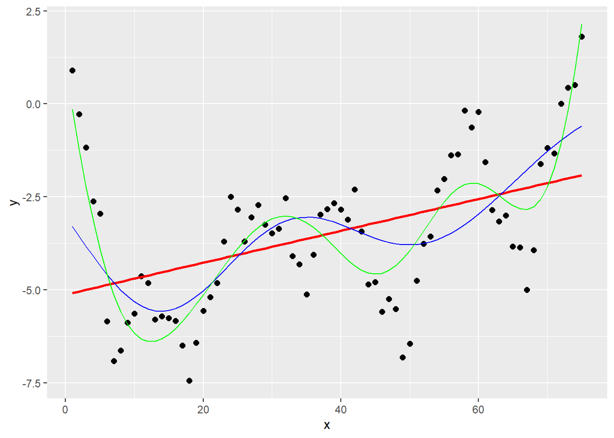

```r
# Predicted vals for all X for tuned
tunedVals <-tuneResult$best.model
predict_svr_tuned <- predict(tunedVals, dat)

# Plot the results along with the linear regression line
ggplot(data = dat, aes(x = x, y = y)) +
  geom_point(size = 2) +
  scale_color_manual(values=c("#000000", "#FF0000")) +
  theme(legend.position = "none") +
  geom_smooth(method = "lm", se = FALSE, color = "red", formula = y ~ x) + # Linear regression
  geom_line(aes(x = x, y = predict_svr), color = "blue") + # SVM regression
  geom_line(aes(x = x, y = predict_svr_tuned), color = "green") # Tuned SVM regression
```

Alternatively, I can also compare the root mean squared errors (RMSE) of different models.

```r
rmse <- function(errval)
{
  val = sqrt(mean(errval^2))
  return(val)
}

errval1 <- fit_linear$residuals
linregress_RMSE <- rmse(errval1)

errval2 <- dat$y - predict_svr
svr_RMSE <- rmse(errval2)
print(paste('svr RMSE = ',
            svr_RMSE))
```

```
## [1] "svr RMSE =  1.52524683594324"
```

```r
errval3 <- dat$y - predict_svr_tuned
svr_RMSE2 <- rmse(errval3)

vals <- matrix(c(linregress_RMSE,svr_RMSE,svr_RMSE2),ncol=3,byrow=TRUE)
colnames(vals) <- c("Linear regress","SVM model","Tuned SVM model")
rownames(vals) <- c("RMSE of model")
as.table(vals)
```

```
##               Linear regress SVM model Tuned SVM model
## RMSE of model       1.851254  1.525247        1.082696
```

# 9 Clustering and PCA

This exercise performs model-based clustering and PCA.

```r
library(tidyverse)
library(MASS) # for mvrnorm
library(mclust) # clustering
```

## 9.1 Model-based Clustering

The most popular clustering approach is the Gaussian mixture model (GMM) where each observation is assumed to be distributed as one of $k$ multivariate-normal distributions, where $k$ is the number of clusters.

GMMs are founded on the multivariate normal (Gaussian) distribution where $p$ variables are assumed to have means and a covariance matrix, which describes the joint variability (i.e., covariance) between each pair of variables. GMMs assume the clusters can be created using $k$ such Gaussian distributions.

First, let’s generate synthetic datasets.

```r
set.seed(123)
# three sets of random correlated variables (that is, clusters)
# cluster 1
mu1 <- c(2, 3)
Sigma1 <- matrix(c(1, 0.8, 0.8, 1), ncol = 2)
cluster1 <- mvrnorm(n = 50, mu = mu1, Sigma = Sigma1)

# cluster 2
mu2 <- c(-2, -2)
Sigma2 <- matrix(c(1, -0.4, -0.4, 1), ncol = 2)
cluster2 <- mvrnorm(n = 50, mu = mu2, Sigma = Sigma2)

# cluster 3
mu3 <- c(3, -2)
Sigma3 <- matrix(c(1, 0.1, 0.1, 1), ncol = 2)
cluster3 <- mvrnorm(n = 50, mu = mu3, Sigma = Sigma3)

data1 <- rbind(cluster1, cluster2, cluster3)
```

Create another scatterplot with different shape/color for each cluster. Note that this shows you the true cluster I would like to estimate using GMM.

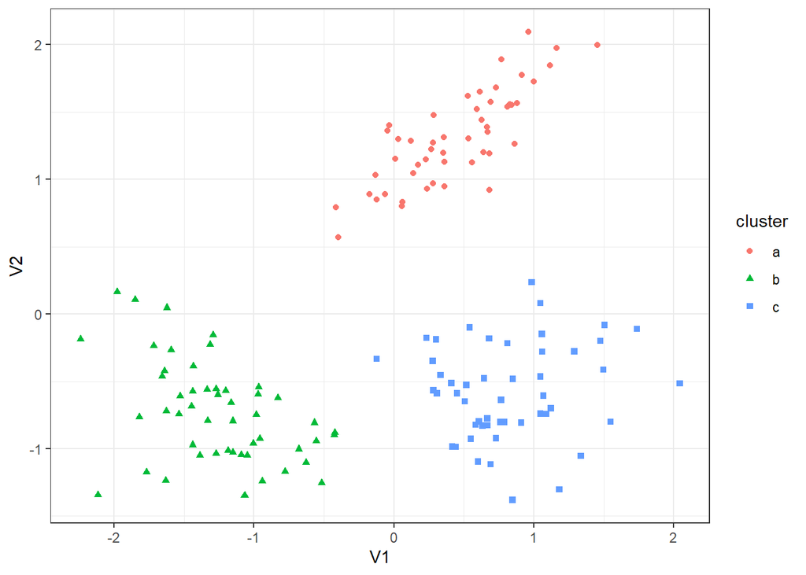

```r
# standardize the variables
data1 <- scale(data1)

# a separate data frame with cluster labels
data1_labeled <- as.data.frame(data1)
data1_labeled$cluster <- c(rep("a", 50), rep("b", 50), rep("c", 50))

# scatterplot with labels
ggplot(data1_labeled, aes(V1, V2, color = cluster, shape = cluster)) +
  geom_point() +
  theme_bw()
```

The covariance matrix describes the geometry of the clusters; namely, the volume, shape, and orientation of the clusters. GMMs allow for flexible clustering structures by adding constraints to the covariance matrix. These constraints can be one or more of the following:

- volume: each cluster has approximately the same number of observations;
- shape: each cluster has approximately the same variance so that the distribution is spherical;
- orientation: each cluster is forced to be axis-aligned.

`Mclust` function from `mclust` package fit models with different $\Sigma$ types and different number of clusters ($k$) by EM algorithm, and then select the best model using a selection criteria such as BIC.

```r
# fit GMM
set.seed(123)
clustering1 <- Mclust(data1)
summary(clustering1)
```

```
## ----------------------------------------------------
## Gaussian finite mixture model fitted by EM algorithm
## ----------------------------------------------------
##
## Mclust VVE (ellipsoidal, equal orientation) model with 3 components:
##
##  log-likelihood   n df       BIC       ICL
##       -276.9643 150 15 -629.0881 -629.5875
##
## Clustering table:
##  1  2  3
## 50 50 50
```

Visualize the performance of different models using BIC. Compare different models and briefly explain the best model.

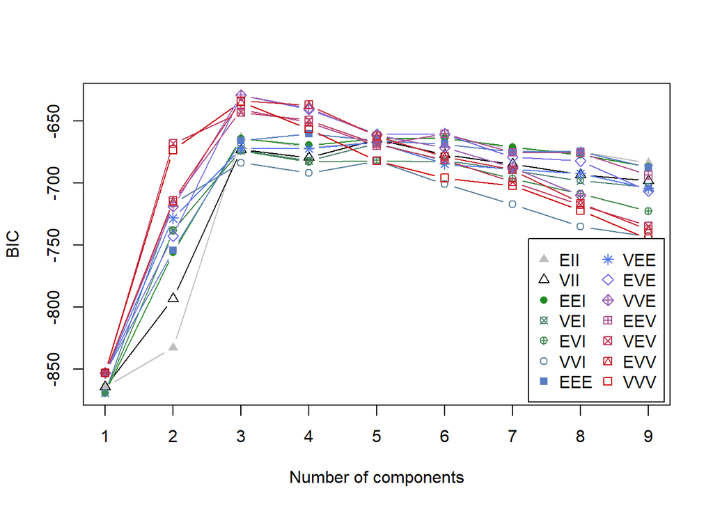

```r
# model selection based on BIC
plot(clustering1, what = "BIC")
```

Create a contingency table with true clusters and estimates from the best fitted model. Visualize the clusters of the best fitted model.

```r
# compare to actual classes
table(clustering1$classification, data1_labeled$cluster)
```

```
##
##      a  b  c
##   1 50  0  0
##   2  0 50  0
##   3  0  0 50
```

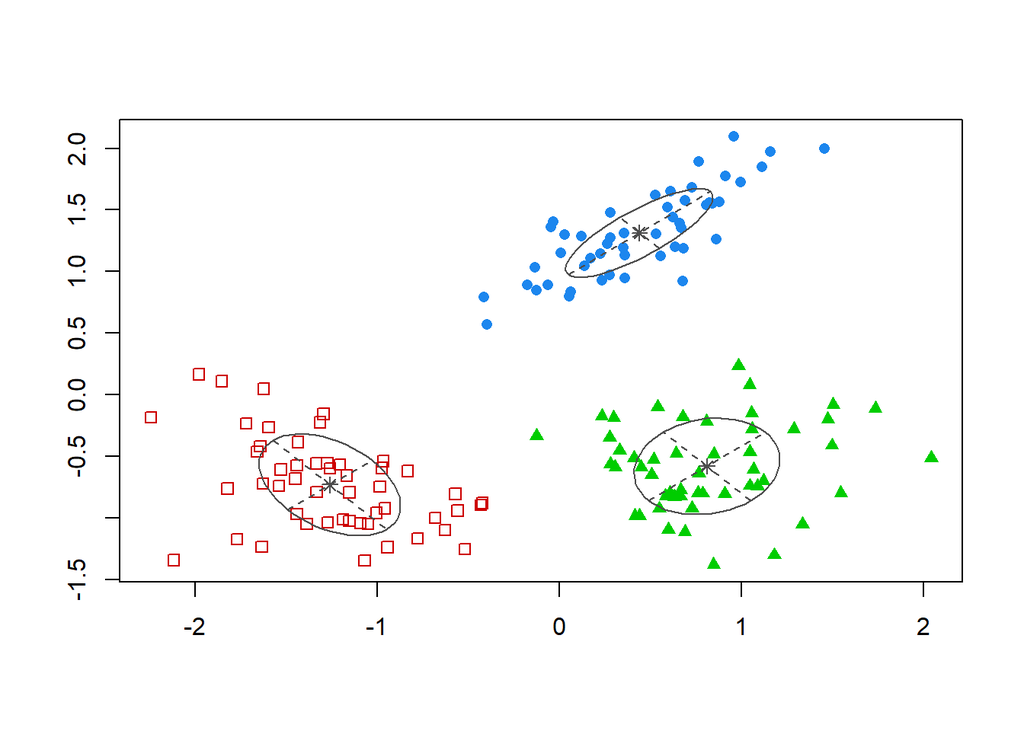

```r
# how the best model classifies observations
plot(clustering1, what = "classification")
```

One of the advantages of using GMM for clustering lies in its use of probability and measure of uncertainty.

```r
# estimated uncertainty of classification
plot(clustering1, what = "uncertainty")
```

[output not shown]

```r
# the observation with maximum uncertainty
round(max(clustering1$uncertainty), 3)
```

```
## [1] 0.086
```

```r
# estimated probability of belonging to a particular cluster
round(clustering1$z[which.max(clustering1$uncertainty),], 3)
```

```
## [1] 0.000 0.914 0.086
```

So far, I did not specify $k$ but used the default values of `G = 1:9` to fit the models for each value and find the best model.

Fit GMM with `G = 2:20` and visualize its BIC and classification result of the best fitted model as before.

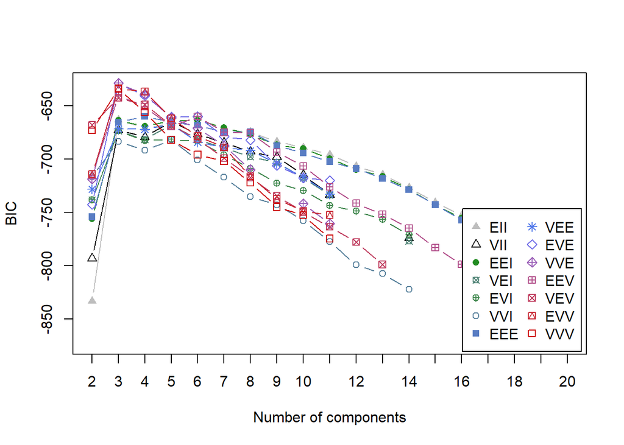

```r
set.seed(123)
# can specify the number of clusters (default is 1 to 9)
clustering2 <- Mclust(data1, G = 2:20)
plot(clustering2, what = "BIC")
```

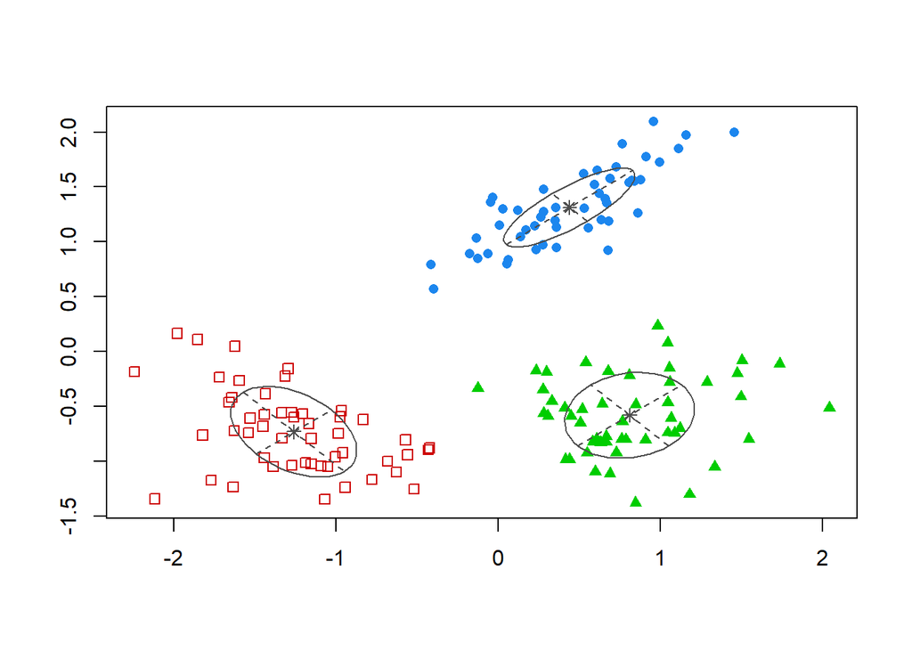

```r
plot(clustering2, what = "classification")
```

## 9.2 Clustering with Real Data

In this question, I will use `iris` dataset with four variables ($p=4$).

```r
# load dataset
iris <- iris
iris_data <- iris[, 1:4]
```

Fit GMM using the dataset and create a contingency table. Visualize BIC, classification, uncertainty as before and observe the results.

```r
clustering3 <- Mclust(iris_data, G = 3)
summary(clustering3)
```

```
## ----------------------------------------------------
## Gaussian finite mixture model fitted by EM algorithm
## ----------------------------------------------------
##
## Mclust VEV (ellipsoidal, equal shape) model with 3 components:
##
##  log-likelihood   n df       BIC       ICL
##        -186.074 150 38 -562.5522 -566.4673
##
## Clustering table:
##  1  2  3
## 50 45 55
```

```r
table(clustering3$classification, iris$Species)
```

```
##
##     setosa versicolor virginica
##   1     50          0         0
##   2      0         45         0
##   3      0          5        50
```

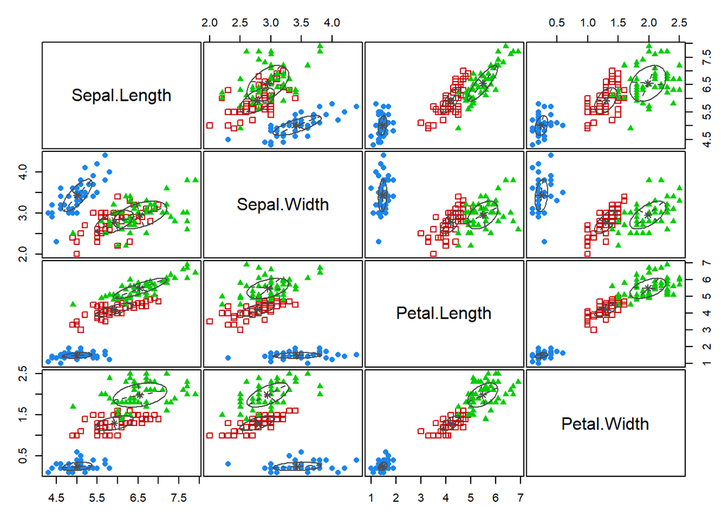

```r
plot(clustering3, what = "classification")
```

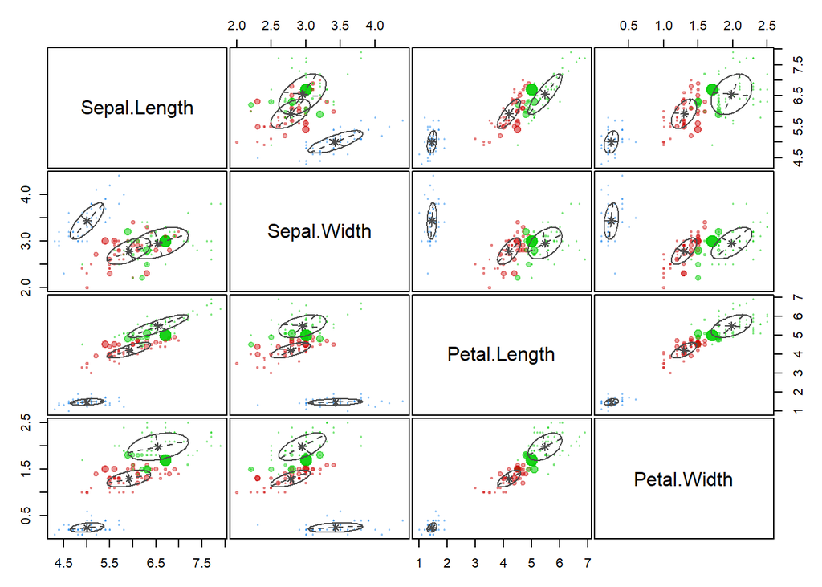

```r
plot(clustering3, what = "uncertainty")
```

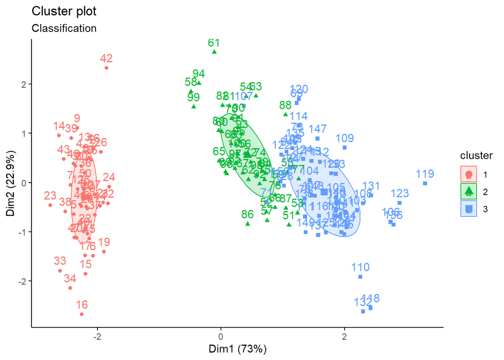

```r
# an alternative plotting library
library(factoextra)
fviz_mclust(clustering3, what = "classification")
```

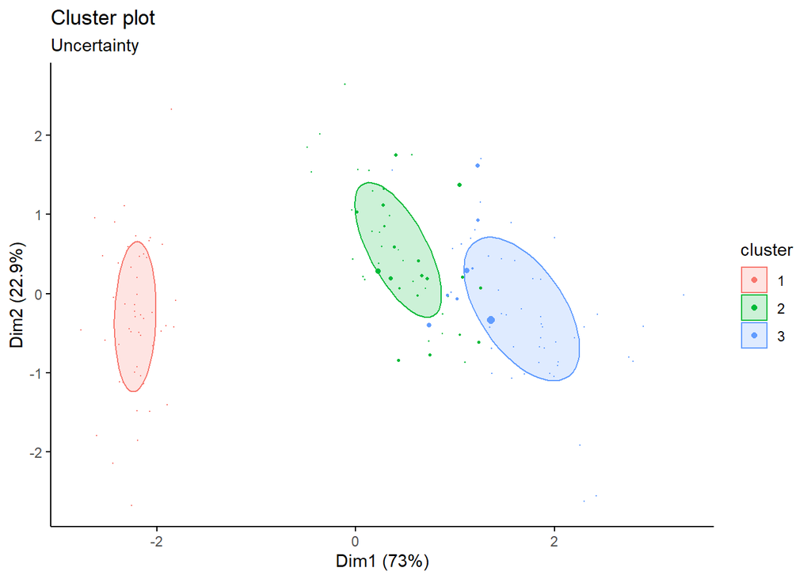

```r
fviz_mclust(clustering3, what = "uncertainty")
```

## 9.3 PCA

The second part of this exercise will be a brief demonstration of principle component analysis. I use PCA to explore and visualize the scored whiskey datasets that you can access from [here](https://www.kaggle.com/datasets/koki25ando/scotch-whisky-dataset).

The data consists of 86 whiskey brands and 12 features about scores on taste including sweetness, smoky, nutty etc.

First load the data.

```r
rm(list=ls())
whiskey <- read.csv("data/whisky.csv")[, c(-1, -2, -15:-17)]
```

## 9.4 Computing PCA

I use the `prcomp` function to conduct PCA.

Use `prcomp` to compute the principle components of the standardized data.

```r
# compute PCA
pca1 <- prcomp(whiskey, scale=TRUE, center = TRUE)
```

The `summary` method describes the importance of the PCs. The first row describes the standard deviation (i.e., the square roots of the eigenvalue) associated with each PC. Larger numbers means this component is more “interesting” or “important” in the sense that it captures more variation.

The second row shows the proportion of the variance in the data explained by each component while the third row describe the cumulative proportion of explained variance.

Print `summary()` of your pca object and observe the result.

```r
summary(pca1)
```

```
## Importance of components:
##                           PC1    PC2    PC3     PC4     PC5     PC6     PC7
## Standard deviation     1.7992 1.3829 1.0968 1.01828 0.97886 0.91625 0.88534
## Proportion of Variance 0.2698 0.1594 0.1003 0.08641 0.07985 0.06996 0.06532
## Cumulative Proportion  0.2698 0.4291 0.5294 0.61579 0.69564 0.76560 0.83092
##                            PC8     PC9   PC10   PC11    PC12
## Standard deviation     0.80493 0.68547 0.6312 0.5288 0.48291
## Proportion of Variance 0.05399 0.03916 0.0332 0.0233 0.01943
## Cumulative Proportion  0.88491 0.92406 0.9573 0.9806 1.00000
```

I can see there that the first two PCs accounts for about 43% of the variance of the data.

Retrive the loadings and scores your pca object and observe the results.

```r
# loadings are contained in the 'rotation' object.
# its columns contain the eigenvectors
loadings <- pca1$rotation
loadings[1:5, 1:5]
```

```
##                  PC1         PC2         PC3         PC4         PC5
## Body       0.2929960 -0.48297574  0.08783807 -0.08564345  0.17745790
## Sweetness -0.2510493  0.01157776  0.45000236 -0.53546754  0.01692593
## Smoky      0.4641307 -0.14107035 -0.15576451  0.02453441  0.03121987
## Medicinal  0.4868911  0.07595446 -0.06629482  0.08063963 -0.00998728
## Tobacco    0.3080273  0.04862369 -0.04571521 -0.18884108 -0.44076420
```

```r
# scores are contained in the 'x' object.
# score are the projections of the centered data in the linear space defined by the eigenvectors of the covariance matrix of X
scores <- pca1$x
scores[1:5, 1:5]
```

```
##             PC1        PC2        PC3        PC4         PC5
## [1,] -0.6518335 -1.1986163  0.1653739  0.7761908 -0.14441886
## [2,] -2.2991462 -3.7261335 -1.3589481 -0.8669076 -0.68962093
## [3,] -1.5928108  0.6602100  0.2954723  1.0963594  0.01526684
## [4,]  5.3820661 -0.2434468 -1.2030860  0.7439419  0.19422806
## [5,]  0.1209399 -0.4103858  0.3026868  1.2631671 -1.48724976
```

## 9.5 Visualizing PCA

I can call `plot` on our PCA object, which returns a scree plot of the variances (y-axis) associated with the PCs (x-axis). Create a scree plot to decide how many PCs to retain for further analysis.

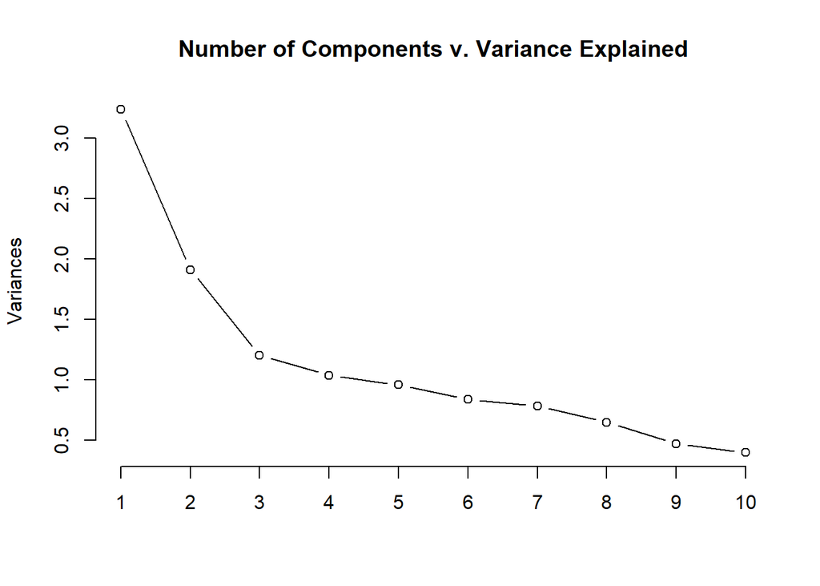

```r
# scree plot
plot(pca1, type="l",main="Number of Components v. Variance Explained")
```

A scree plot shows the eigenvalues or PVE for each individual PC. Most scree plots look broadly similar in shape, starting high on the left, falling rather quickly, and then flattening out at some point. This is because the first component usually explains much of the variability, the next few components explain a moderate amount, and the latter components only explain a small fraction of the overall variability. The scree plot criterion looks for the “elbow” in the curve and selects all components just before the line flattens out, which looks like three in our example.

Run `biplot` funcion with the pca object to visualize both PC loadings and scores.

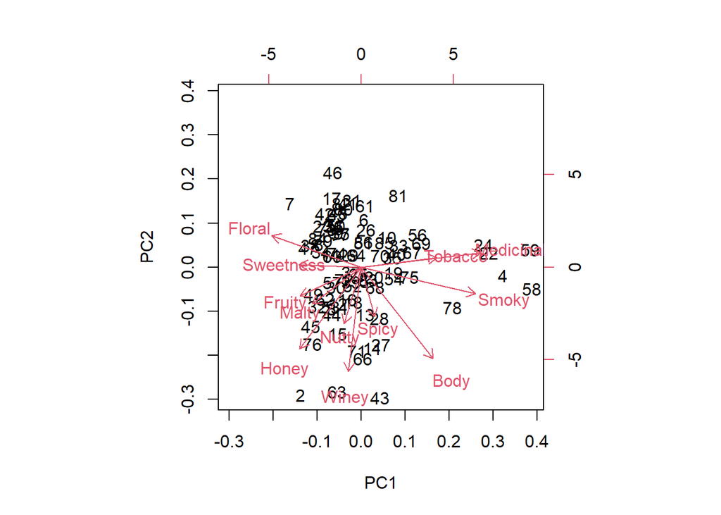

```r
# biplot
biplot(pca1)
```

The `ggfortify` package lets `ggplot2` know how to interpret PCA objects. After installing and loading `ggfortify`, run the `autoplot` function with your pca object.

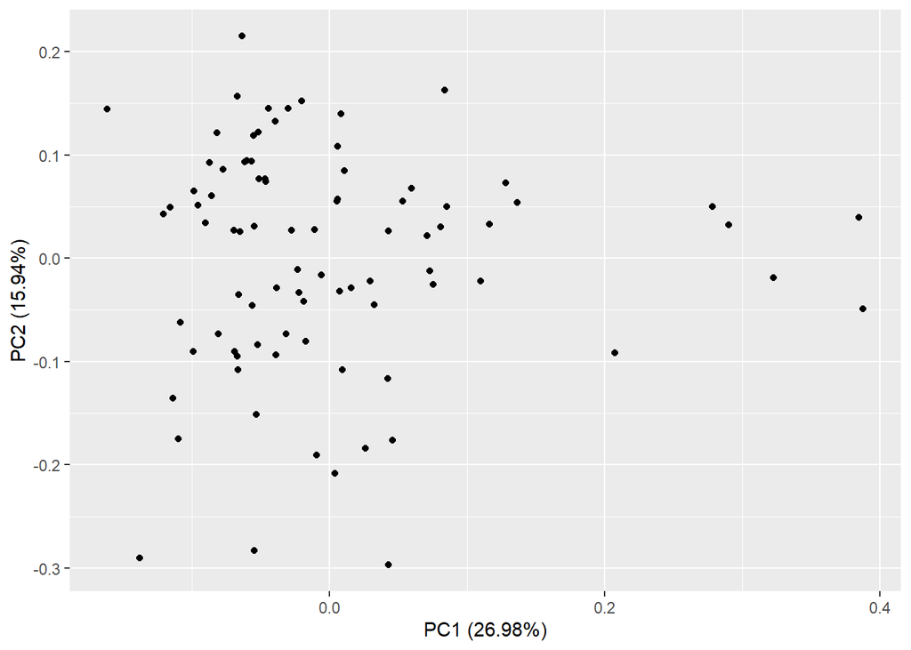

```r
library(ggfortify)

autoplot(pca1)
```

Passing `shape = FALSE` makes plot with labels instead of points.

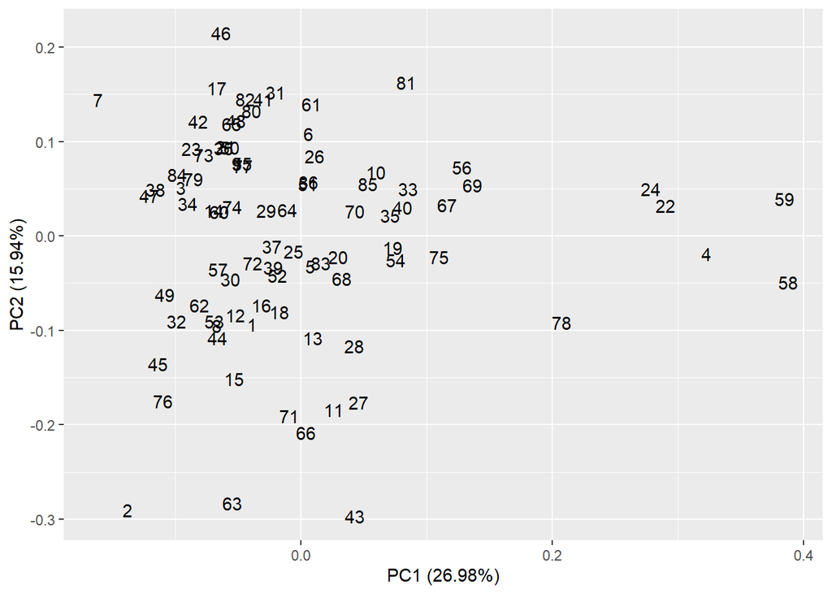

```r
autoplot(pca1, shape = F)
```

Plot loadings with `loadings = TRUE`

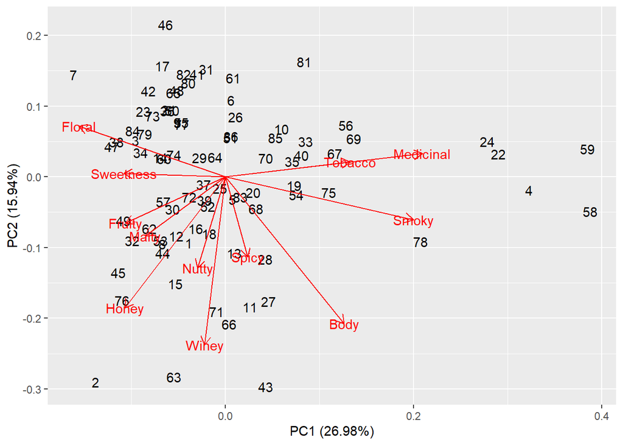

```r
autoplot(pca1, shape = F,
         loadings = T,
         loadings.label = T)
```